## Practical Machine Learning - Final Project

### Background

Using devices such as Jawbone Up, Nike FuelBand, and Fitbit it is now possible to collect a large amount of data about personal activity relatively inexpensively. These type of devices are part of the quantified self movement – a group of enthusiasts who take measurements about themselves regularly to improve their health, to find patterns in their behavior, or because they are tech geeks. One thing that people regularly do is quantify how much of a particular activity they do, but they rarely quantify how well they do it. In this project, your goal will be to use data from accelerometers on the belt, forearm, arm, and dumbell of 6 participants. They were asked to perform barbell lifts correctly and incorrectly in 5 different ways. More information is available from the website here: http://groupware.les.inf.puc-rio.br/har (see the section on the Weight Lifting Exercise Dataset).

### Loading Data

In this project I mainly I will use the caret Package. I load the package then load the data.

```r
library(caret)
train_data <- read.csv('pml-training.csv',na.strings=c("NA",""), header=T)
test_data <- read.csv('pml-testing.csv',na.strings=c("NA",""), header=T)
dim(train_data)
```

```
## [1] 19622   160
```

```r
dim(test_data)
```

```
## [1]  20 160
```

Data has many NA values. Also in any dataset there could be a parameter which is not changing considerably and has not effect in the classification process. I remove the mostly NA and also near zero variance columns.

```r
# Remove columns with more than 95 percent of NA value

na_train_data <- sapply(train_data, function(x) mean(is.na(x))) > 0.95
na_test_data <- sapply(test_data, function(x) mean(is.na(x))) > 0.95

train_data_wo_na <- train_data[, na_train_data==F]
test_data_wo_na <- test_data[, na_test_data==F]


# remove variables with Nearly Zero Variance
nzv <- nearZeroVar(train_data_wo_na)
train_data_prep <- train_data_wo_na[, -nzv]
test_data_prep  <- test_data_wo_na[, -nzv]

head(train_data_prep)
```

```
##   X user_name raw_timestamp_part_1 raw_timestamp_part_2   cvtd_timestamp
## 1 1  carlitos           1323084231               788290 05/12/2011 11:23
## 2 2  carlitos           1323084231               808298 05/12/2011 11:23
## 3 3  carlitos           1323084231               820366 05/12/2011 11:23
## 4 4  carlitos           1323084232               120339 05/12/2011 11:23
## 5 5  carlitos           1323084232               196328 05/12/2011 11:23
## 6 6  carlitos           1323084232               304277 05/12/2011 11:23
##   num_window roll_belt pitch_belt yaw_belt total_accel_belt gyros_belt_x
## 1         11      1.41       8.07    -94.4                3         0.00
## 2         11      1.41       8.07    -94.4                3         0.02
## 3         11      1.42       8.07    -94.4                3         0.00
## 4         12      1.48       8.05    -94.4                3         0.02
## 5         12      1.48       8.07    -94.4                3         0.02
## 6         12      1.45       8.06    -94.4                3         0.02
##   gyros_belt_y gyros_belt_z accel_belt_x accel_belt_y accel_belt_z
```

[output cut: 76 more lines]

At the next step, I take a look at the fields to see which of them will be helpful in classification process.

```r
names(train_data_prep)
```

```
##  [1] "X"                    "user_name"            "raw_timestamp_part_1"
##  [4] "raw_timestamp_part_2" "cvtd_timestamp"       "num_window"
##  [7] "roll_belt"            "pitch_belt"           "yaw_belt"
## [10] "total_accel_belt"     "gyros_belt_x"         "gyros_belt_y"
## [13] "gyros_belt_z"         "accel_belt_x"         "accel_belt_y"
## [16] "accel_belt_z"         "magnet_belt_x"        "magnet_belt_y"
## [19] "magnet_belt_z"        "roll_arm"             "pitch_arm"
## [22] "yaw_arm"              "total_accel_arm"      "gyros_arm_x"
## [25] "gyros_arm_y"          "gyros_arm_z"          "accel_arm_x"
## [28] "accel_arm_y"          "accel_arm_z"          "magnet_arm_x"
## [31] "magnet_arm_y"         "magnet_arm_z"         "roll_dumbbell"
## [34] "pitch_dumbbell"       "yaw_dumbbell"         "total_accel_dumbbell"
## [37] "gyros_dumbbell_x"     "gyros_dumbbell_y"     "gyros_dumbbell_z"
## [40] "accel_dumbbell_x"     "accel_dumbbell_y"     "accel_dumbbell_z"
## [43] "magnet_dumbbell_x"    "magnet_dumbbell_y"    "magnet_dumbbell_z"
## [46] "roll_forearm"         "pitch_forearm"        "yaw_forearm"
## [49] "total_accel_forearm"  "gyros_forearm_x"      "gyros_forearm_y"
## [52] "gyros_forearm_z"      "accel_forearm_x"      "accel_forearm_y"
## [55] "accel_forearm_z"      "magnet_forearm_x"     "magnet_forearm_y"
## [58] "magnet_forearm_z"     "classe"
```

Based on the results, I remove the first 5 columns which are number, username and time stamps.

```r
train_data_prep1 <- train_data_prep[, -c(1:5)]
test_data_prep1 <- test_data_prep[, -c(1:5)]
```

At the next step I need to split the training data into train and validation data. Since we have large amount of training data, I choose 70% for training and 30% for validation.

```r
Td <- createDataPartition(train_data_prep1$classe, p = 0.7, list = FALSE)
train_final <- train_data_prep1[Td, ]
valid_final <- train_data_prep1[-Td, ]
```

We loaded, cleaned, and preprocess the data.

### Prediction

In this section I will use the training, validation, and test data to develop a prediction algorithm. I use two common methods, which are classification tree and random forest. For the classification tree I use 10-fold cross validation.

#### Classificaiton Tree Approach

```r
set.seed(7000)
train_control <- trainControl(method = "cv", number = 10)
trained_ct <- train(classe ~ ., data = train_final, method = "rpart",
                   trControl = train_control)
print(trained_ct, digits = 4)
```

```
## CART
##
## 13737 samples
##    53 predictor
##     5 classes: 'A', 'B', 'C', 'D', 'E'
##
## No pre-processing
## Resampling: Cross-Validated (10 fold)
## Summary of sample sizes: 12363, 12361, 12365, 12362, 12364, 12363, ...
## Resampling results across tuning parameters:
##
##   cp       Accuracy  Kappa
##   0.03911  0.5295    0.3961
##   0.06059  0.4304    0.2321
##   0.11606  0.3576    0.1120
##
## Accuracy was used to select the optimal model using  the largest value.
## The final value used for the model was cp = 0.03911.
```

```r
library(rattle)
```

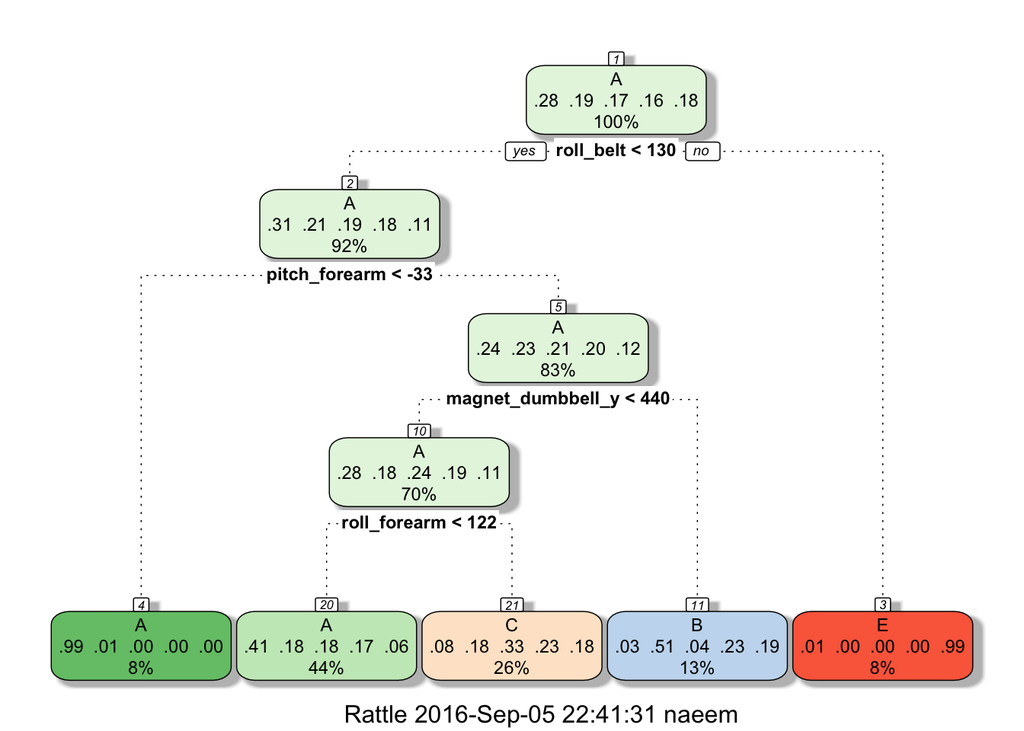

```r
fancyRpartPlot(trained_ct$finalModel)
```

```r
predict_valid_data_tr <- predict(trained_ct, valid_final)
(confusion_mat_tr <- confusionMatrix(valid_final$classe, predict_valid_data_tr))
```

```
## Confusion Matrix and Statistics
##
##           Reference
## Prediction    A    B    C    D    E
##          A 1509   33  128    0    4
##          B  477  377  285    0    0
##          C  472   29  525    0    0
##          D  430  163  371    0    0
##          E  153  143  306    0  480
##
## Overall Statistics
##
##                Accuracy : 0.4912
##                  95% CI : (0.4784, 0.5041)
##     No Information Rate : 0.5167
##     P-Value [Acc > NIR] : 1
##
##                   Kappa : 0.3354
##  Mcnemar's Test P-Value : NA
##
## Statistics by Class:
##
##                      Class: A Class: B Class: C Class: D Class: E
## Sensitivity            0.4962  0.50604  0.32508       NA  0.99174
## Specificity            0.9420  0.85175  0.88267   0.8362  0.88854
## Pos Pred Value         0.9014  0.33099  0.51170       NA  0.44362
## Neg Pred Value         0.6362  0.92246  0.77567       NA  0.99917
## Prevalence             0.5167  0.12659  0.27443   0.0000  0.08224
## Detection Rate         0.2564  0.06406  0.08921   0.0000  0.08156
## Detection Prevalence   0.2845  0.19354  0.17434   0.1638  0.18386
## Balanced Accuracy      0.7191  0.67890  0.60387       NA  0.94014
```

```r
(accuracy <- confusion_mat_tr$overall[1])
```

```
##  Accuracy
## 0.4912489
```

#### Random Forest Approach

After the classification tree approach we try the random forest approach.

```r
set.seed(7000)
trained_rf <- train(classe ~ ., data = train_final, method = "rf",
                   trControl = train_control, allowParallel=TRUE, ntree=10)
print(trained_rf , digits = 4)
```

```
## Random Forest
##
## 13737 samples
##    53 predictor
##     5 classes: 'A', 'B', 'C', 'D', 'E'
##
## No pre-processing
## Resampling: Cross-Validated (10 fold)
## Summary of sample sizes: 12363, 12361, 12365, 12362, 12364, 12363, ...
## Resampling results across tuning parameters:
##
##   mtry  Accuracy  Kappa
##    2    0.9851    0.9811
##   27    0.9935    0.9918
##   53    0.9919    0.9898
##
## Accuracy was used to select the optimal model using  the largest value.
## The final value used for the model was mtry = 27.
```

```r
predict_valid_data_rf <- predict(trained_rf, valid_final)
(confusion_mat_rf <- confusionMatrix(valid_final$classe, predict_valid_data_rf))
```

```
## Confusion Matrix and Statistics
##
##           Reference
## Prediction    A    B    C    D    E
##          A 1674    0    0    0    0
##          B    2 1131    3    2    1
##          C    0    4 1021    1    0
##          D    0    0   14  950    0
##          E    0    0    0    3 1079
##
## Overall Statistics
##
##                Accuracy : 0.9949
##                  95% CI : (0.9927, 0.9966)
##     No Information Rate : 0.2848
##     P-Value [Acc > NIR] : < 2.2e-16
##
##                   Kappa : 0.9936
##  Mcnemar's Test P-Value : NA
##
## Statistics by Class:
##
##                      Class: A Class: B Class: C Class: D Class: E
## Sensitivity            0.9988   0.9965   0.9836   0.9937   0.9991
## Specificity            1.0000   0.9983   0.9990   0.9972   0.9994
## Pos Pred Value         1.0000   0.9930   0.9951   0.9855   0.9972
## Neg Pred Value         0.9995   0.9992   0.9965   0.9988   0.9998
## Prevalence             0.2848   0.1929   0.1764   0.1624   0.1835
## Detection Rate         0.2845   0.1922   0.1735   0.1614   0.1833
## Detection Prevalence   0.2845   0.1935   0.1743   0.1638   0.1839
## Balanced Accuracy      0.9994   0.9974   0.9913   0.9954   0.9992
```

```r
(accuracy <- confusion_mat_rf$overall[1])
```

```
##  Accuracy
## 0.9949023
```

We used to method. Based on the accuracy of the random forest method is much better than the classification tree approach. Now we predict the values for the test data.

```r
test_predict <- predict(trained_rf, test_data_prep1)
test_predict
```

```
##  [1] B A B A A E D B A A B C B A E E A B B B
## Levels: A B C D E
```

### Data and Resources

The data for this project come from this source: http://groupware.les.inf.puc-rio.br/har.